# 統繪_R程式整理

曾郁珉

#### Homework 1

**1.** Use seq() and rep() to write codes for the following questions:

1. Construct a vector as the same output as: 1 2 3 4 5 2 3 4 5 6 3 4 5 6 7 4 5 6 7 8 5 6 7 8 9

```r
  rep(seq(1,5),5) + rep(seq(0,4),each=5)
```

```
##  [1] 1 2 3 4 5 2 3 4 5 6 3 4 5 6 7 4 5 6 7 8 5 6 7 8 9
```

2. Construct a vector as the same output as: 1 2 3 4 5 1 2 3 4 5 1 2 3 4 5 1 2 3 4 5 1 2 3 4 5

```r
rep(seq(1,5),5)
```

```
##  [1] 1 2 3 4 5 1 2 3 4 5 1 2 3 4 5 1 2 3 4 5 1 2 3 4 5
```

3. Construct a vector as the same output as: 0 0 0 0 0 1 1 1 1 1 2 2 2 2 2 3 3 3 3 3 4 4 4 4 4

```r
rep(seq(0,4) , rep(5,5))
```

```
##  [1] 0 0 0 0 0 1 1 1 1 1 2 2 2 2 2 3 3 3 3 3 4 4 4 4 4
```

4. Let more.color be defined as follows.

   more.color <- c(“red”,“yellow”,“blue”,“green”,“magenta”,“cyan”)

   Use more.color, seq(), and rep() to create a vector as follows:

   “red” “yellow” “blue” “yellow” “blue” “green” “blue” “green” “magenta” “green” “magenta” “cyan”

   Give the name “color.vec” to this created vector.

```r
more.color <- c("red","yellow","blue","green","magenta","cyan")
color.vec <- more.color[ rep(seq(1,3),4) + rep(seq(0,3),each=3) ]
```

5. According to (d), how many colors in color.vec?

```r
length(unique(color.vec))
```

```
## [1] 6
```

6. According to (d), how many times does each color appear in color.vec?

```r
table(color.vec)
```

```
## color.vec
##    blue    cyan   green magenta     red  yellow
##       3       1       3       2       1       2
```

7. Rearrange the order in color.vec by letting the first letter from z to a.

```r
sort(color.vec , decreasing = TRUE)
```

```
##  [1] "yellow"  "yellow"  "red"     "magenta" "magenta" "green"   "green"
##  [8] "green"   "cyan"    "blue"    "blue"    "blue"
```

**2.** Use seq(), rep(), and vector calculation in R to write codes for the following questions.(Do not use “for loop”.)

1. Calculate the values of $\sum_{j=1}^{n} j^2$ when n = 200, 400, 600, 800.

```r
c(sum(seq(1,200)^2) , sum(seq(1,400)^2) , sum(seq(1,600)^2) ,
sum(seq(1,800)^2))
```

```
## [1]   2686700  21413400  72180100 170986800
```

2. Calculate the values of $n(n+1)(2n+1)/6$ when n = 200, 400, 600, 800.

```r
n=seq(200,800,200) ; n*(n+1)*(2*n+1)/6
```

```
## [1]   2686700  21413400  72180100 170986800
```

3. Check if the values of (a) and (b) are the same. (The output should show either TRUE or FALSE.)

```r
c(sum(seq(1,200)^2),sum(seq(1,400)^2),sum(seq(1,600)^2),sum(seq(1,800)^2)) == n*(n+1)*(2*n+1)/6
```

```
## [1] TRUE TRUE TRUE TRUE
```

**3.** score0 <- c(81.2, 89.6, 64.2, 91.3, 77.4, 84.5, NA, 91.7, 63.5, 84.8, NA, 87.8, 87.9, 80.9, 74.8, 64.3, 78.7, 91.3, 76.9, 74.9, 87.6, 88.4)

1. Typing mean(score0) and max(score0), what results do you get?

```r
score0 <- c(81.2, 89.6, 64.2, 91.3, 77.4, 84.5, NA, 91.7, 63.5, 84.8, NA, 87.8, 87.9, 80.9, 74.8, 64.3, 78.7, 91.3, 76.9, 74.9, 87.6, 88.4)
c(mean(score0) , max(score0))
```

```
## [1] NA NA
```

2. How to modify mean() and max() so that you can get the numeric answers?

```r
c(mean(score0,na.rm = TRUE) , max(score0,na.rm = TRUE))
```

```
## [1] 81.085 91.700
```

3. Delete NA from the vector score0 and assign the name score1 to the new vector. What do you get if you type mean(score1) and max(score1)? Are the answers the same as those in (b)?

```r
score1<-na.omit(score0) ; c(mean(score1) , max(score1))
```

```
## [1] 81.085 91.700
```

```r
c(mean(score0,na.rm = TRUE) , max(score0,na.rm = TRUE)) ==
c(mean(score1),max(score1))
```

```
## [1] TRUE TRUE
```

4. If I obtain two scores, 67.2 and 89.5, try to change the values in score0 from NA to 67.2 and 89.5, and assign the name score2 to the new vector.

```r
score2 <- score0
score2[which(is.na(score0))] <- c(67.2,89.5)
```

5. What do you get if you type mean(score2) and max(score2)?

```r
c(mean(score2),max(score2))
```

```
## [1] 80.83636 91.70000
```

#### Homework 2

**1.** Rolling two fair dices, evaluate the total number that all possible outcomes occur at least once. The events are as follows, and each row has two outcomes of dices.

```r
two.dice<-matrix( c(3, 5, 5, 4, 4, 3, 4, 5, 5, 2, 3, 2, 6, 6, 6,
                    3, 6, 2, 1, 2, 5, 6, 1, 5, 6, 1, 3, 6, 6, 3,
                    5, 3, 3, 5, 3, 3, 4, 2, 1, 4, 3, 1, 5, 1, 6,
                    4, 5, 5, 3, 5, 2, 2, 1, 2, 2, 6, 1, 3, 4, 5,
                    6, 4, 3, 3, 6, 1, 2, 1, 4, 5, 1, 1, 2, 3, 6,
                    5, 6, 5, 3, 1, 4, 1, 5, 2, 2, 6, 3, 2, 3, 1,
                    5, 1, 2, 5, 1, 1, 1, 3, 1, 3, 4, 1, 6, 5, 1,
                    5, 6, 6, 5, 5, 2, 4, 1, 3, 5, 2, 1, 1, 1, 1),
                  ncol = 2)
total=c()
for(i in 1:dim(two.dice)[1]){
  total<-c(total,sum(two.dice[i,]))
}

i<-0;n<-c()
while(length(unique(n))<11){
  i<-i+1
  n<-c(n,total[i])
}
cat('Total number:',i)
```

```
## Total number: 43
```

**2.** Let $U_1$, . . . , $U_k$ be from a uniform(0,1). Define
$$N = max \left\{ n : \prod_{i=1}^n U_i > 10^{-8} \right\}.$$

What is the value of N if you use the following sequence?

U <- c(0.89, 0.03, 0.52, 0.41, 0.09, 0.37, 0.71, 0.29, 0.01, 0.92, 0.53, 0.14, 0.64, 0.94, 0.89, 0.19, 0.33, 0.31, 0.24, 0.15)

You should use at least one of for( ), while( ), and if( ).

```r
U<-c(0.89, 0.03, 0.52, 0.41, 0.09, 0.37, 0.71, 0.29, 0.01, 0.92, 0.53, 0.14, 0.64, 0.94, 0.89, 0.19, 0.33, 0.31, 0.24, 0.15)
x<-1;i<-0
while(x>1e-8){
  i<-i+1
  x<-x*U[i]
}
cat('N:',i-1)
```

```
## N: 15
```

**3.** Collect students’ scores of math and English as follows:

Math <- c(79, 61, 76, 40, 51, 98, 48, 34, 54, 51, 45, 61, 75, 42, 32, 61, 56, 82, 22, 33, 19, 60, 91, 49, 44)

English <- c(87, 54, 96, 63, 58, 75, 60, 74, 46, 94, 57, 69, 69, 55, 79, 94, 72, 86, 85, 56, 62, 77, 78, 62, 56)

1. Construct a matrix with two columns to collect these scores. The first column is for math and the second column is for English. Assign the names for the columns as “Math” and “English”, respectively, and assign the ID numbers for the rows from 1 to the total number of the students. Assign the name to the matrix as “scores”.

```r
Math <- c(79, 61, 76, 40, 51, 98, 48, 34, 54, 51, 45, 61, 75, 42, 32, 61, 56, 82, 22, 33, 19, 60, 91, 49, 44)
English <- c(87, 54, 96, 63, 58, 75, 60, 74, 46, 94, 57, 69, 69, 55, 79, 94, 72, 86, 85, 56, 62, 77, 78, 62, 56)
scores<-matrix(c(Math,English),length(c(Math)),2)
colnames(scores)<-c('Math','English')
row.names(scores)<-c(1:length(Math))
print(scores)
```

```
##    Math English
## 1    79      87
## 2    61      54
## 3    76      96
## 4    40      63
## 5    51      58
## 6    98      75
## 7    48      60
## 8    34      74
## 9    54      46
## 10   51      94
## 11   45      57
## 12   61      69
## 13   75      69
## 14   42      55
## 15   32      79
## 16   61      94
## 17   56      72
## 18   82      86
## 19   22      85
## 20   33      56
## 21   19      62
## 22   60      77
## 23   91      78
## 24   49      62
## 25   44      56
```

2. Classify the students by the scores. Define the student passes the class if the score is greater or equal to 60, and the student gets a fail if the score is less than 60. Summarize the number of each of the following event:

   A: Math ≥ 60 and English ≥ 60;

   B: Math ≥ 60 and English < 60;

   C: Math < 60 and English ≥ 60;

   D: Math < 60 and English < 60.

```r
A<-sum(scores[,c('Math')]>=60 & scores[,c('English')]>=60)
B<-sum(scores[,c('Math')]>=60 & scores[,c('English')]<60)
C<-sum(scores[,c('Math')]<60 & scores[,c('English')]>=60)
D<-sum(scores[,c('Math')]<60 & scores[,c('English')]<60)
cat('Number of each group\nA:',A,'\nB:',B,'\nC:',C,'\nD:',D)
```

```
## Number of each group
## A: 9
## B: 1
## C: 9
## D: 6
```

3. Provide the students’ ID numbers in each category (A, B, C, D).

```r
A<-which(scores[,c('Math')]>=60 & scores[,c('English')]>=60)
B<-which(scores[,c('Math')]>=60 & scores[,c('English')]<60)
C<-which(scores[,c('Math')]<60 & scores[,c('English')]>=60)
D<-which(scores[,c('Math')]<60 & scores[,c('English')]<60)
cat('ID numbers\nA:',A,'\nB:',B,'\nC:',C,'\nD:',D)
```

```
## ID numbers
## A: 1 3 6 12 13 16 18 22 23
## B: 2
## C: 4 7 8 10 15 17 19 21 24
## D: 5 9 11 14 20 25
```

**4.** When you enter a vector including {5, 10, 11, 1, 0, 3, 8, 10, 4, 0, 1, 6, 7, 10, 7, 0}, treat 0 as a missing value.

Delete all missing values and evaluate the following questions:

1. Sum of the values in the vector;
2. The length of the input vector;
3. The average of the values in the vector;
4. The number of odd values in the vector;
5. The number of 10 in the vector;
6. The maximum of the values in the vector.

```r
a<-c(5,10,11,1,0,3,8,10,4,0,1,6,7,10,7,0)
b<-a[a!=FALSE]
cat('(1) Sum:',sum(b),'\n(2) length:',length(b),
    '\n(3) Average:',mean(b),'\n(4) # of odd:',sum(b%%2==1),
    '\n(5) # of 10:',sum(b==10),'\n(6) Max:',max(b))
```

```
## (1) Sum: 83
## (2) length: 13
## (3) Average: 6.384615
## (4) # of odd: 7
## (5) # of 10: 3
## (6) Max: 11
```

Apply the code to the vector {7, 5, 0, 1, 2, 7, 1, 10, 5, 0, 3, 7, 2, 3, 3} and print the results from (1) to (6).

```r
a<-c(7,5,0,1,2,7,1,10,5,0,3,7,2,3,3)
b<-a[a!=FALSE]
cat('(1) Sum:',sum(b),'\n(2) length:',length(b),
    '\n(3) Average:',mean(b),'\n(4) # of odd:',sum(b%%2==1),
    '\n(5) # of 10:',sum(b==10),'\n(6) Max:',max(b))
```

```
## (1) Sum: 56
## (2) length: 13
## (3) Average: 4.307692
## (4) # of odd: 10
## (5) # of 10: 1
## (6) Max: 10
```

#### Homework 3

**1.** Write Rmarkdown codes to provide the expression of probability density function (pdf) or probability mass function (pmf) of the following distribution.

1. Binomial distribution with parameters *n* and *p* with $x = 0,...,n$
- Ans : 在 n 次實驗中有 k 次成功的機率為
  $$f(x)={n \choose k}p^{k}(1-p)^{n-k}$$
  $\text{where x = 0,...,n}$
2. Gamma distribution with shape parameter $\alpha$ and the rate parameter $\lambda$ with $x > 0$
- Ans :
  $$f(x)=\frac{x^{(\alpha-1)}\lambda^\alpha e^{(-\lambda x)}}{\Gamma (\alpha)}$$
  $\text{where x > 0}$
  $$\text{其中 $\Gamma(\alpha)$ = $\int_0^\infty t^{\alpha-1}e^{-t}dt,\alpha>0$}$$
  $\text{where $\begin{cases} \Gamma(\alpha)=(\alpha-1)!, &\text{if $\alpha$ is $\mathbb{Z}^+$} \\ \Gamma(\alpha)=(\alpha-1)\Gamma(\alpha-1), &\text{if $\alpha$ is $\mathbb{R}^+$}\\ \Gamma(\frac{1}{2})=\sqrt{\pi}\\ \end{cases}$}$
3. Normal distribution with parameters $\mu$ and $\sigma^2$ with $-\infty<x<\infty$
- Ans :
  $$f(x)=\frac{1}{\sigma\sqrt{2\pi}}exp\left(-\frac{(x-\mu)^2}{2\sigma^2}\right)$$
  $\text{where $-\infty$ < x < $\infty$}$

**2.** Draw the pdf(or pmf) of each distribution in Question 1.

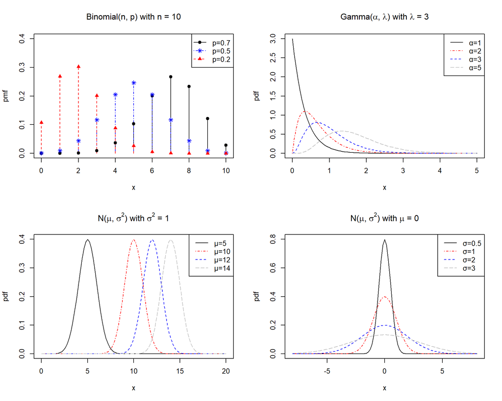

#### Midterm Exam

```r
a<-c('Isla','Silas','Olivia','Theodore','Posie','Jack')
b<-c('Finn','Aurora','Aarav','Cora','Felix','Ada')
c<-c('Maeve','Henry','Amara','Wyatt','Charlotte','Aryan')
class<-rbind(c('Isla','Silas','Olivia','Theodore','Posie','Jack'),
             c('Finn','Aurora','Aarav','Cora','Felix','Ada'),
             c('Maeve','Henry','Amara','Wyatt','Charlotte','Aryan'))
class
```

```
##      [,1]    [,2]     [,3]     [,4]       [,5]        [,6]
## [1,] "Isla"  "Silas"  "Olivia" "Theodore" "Posie"     "Jack"
## [2,] "Finn"  "Aurora" "Aarav"  "Cora"     "Felix"     "Ada"
## [3,] "Maeve" "Henry"  "Amara"  "Wyatt"    "Charlotte" "Aryan"
```

2. What is the name if you type **class[8]**.

```r
class[8]
```

```
## [1] "Aarav"
```

```r
a<-which(class=='Jack')
b<-which(class=='Henry')
class[a]<-'Henry'
class[b]<-'Jack'
class
```

```
##      [,1]    [,2]     [,3]     [,4]       [,5]        [,6]
## [1,] "Isla"  "Silas"  "Olivia" "Theodore" "Posie"     "Henry"
## [2,] "Finn"  "Aurora" "Aarav"  "Cora"     "Felix"     "Ada"
## [3,] "Maeve" "Jack"   "Amara"  "Wyatt"    "Charlotte" "Aryan"
```

6. There are six new students, but you do not know their names. You make labels for the six students as (S1, S2, S3, S4, S5, S6) and assign them to be seated at the last row. Write a code to show this result.

```r
class<-rbind(class,c('s1','s2','s3','s4','s5','s6'))
class
```

```
##      [,1]    [,2]     [,3]     [,4]       [,5]        [,6]
## [1,] "Isla"  "Silas"  "Olivia" "Theodore" "Posie"     "Henry"
## [2,] "Finn"  "Aurora" "Aarav"  "Cora"     "Felix"     "Ada"
## [3,] "Maeve" "Jack"   "Amara"  "Wyatt"    "Charlotte" "Aryan"
## [4,] "s1"    "s2"     "s3"     "s4"       "s5"        "s6"
```

7. After the class, you knows their names: - S3: Kelly - S4: Ben - S5: Susan - S6: Jackson - S1: Helen - S2: Owen. Modify the seat matrix in (f).

```r
class[which(class=='s1')]<-'Helen'
class[which(class=='s2')]<-'Owen'
class[which(class=='s3')]<-'Kelly'
class[which(class=='s4')]<-'Ben'
class[which(class=='s5')]<-'Susan'
class[which(class=='s6')]<-'Jackson'
class
```

```
##      [,1]    [,2]     [,3]     [,4]       [,5]        [,6]
## [1,] "Isla"  "Silas"  "Olivia" "Theodore" "Posie"     "Henry"
## [2,] "Finn"  "Aurora" "Aarav"  "Cora"     "Felix"     "Ada"
## [3,] "Maeve" "Jack"   "Amara"  "Wyatt"    "Charlotte" "Aryan"
## [4,] "Helen" "Owen"   "Kelly"  "Ben"      "Susan"     "Jackson"
```

**4.** A pair of fair dice are to be continually rolled until all the possible outcomes 2, 3, . . ., 12 have occurred at least once. Develop a function to collect the total number of rolls. Conduct the code for 10000 times and give the average of the 10000 rolls. Is it possible that the total number of rolls is 11? How many times do you get the result that the number of rolls is 11?

```r
f <- function(n){
  total<-c()
  for(i in 1:n){
    a<-c()
    while(length(unique(a))<11){
      a<-c(a,sample(2:12,size=1))
    }
  total<-c(total,length(a))
  }
  return(total)
}

mean(f(10000))
```

```
## [1] 33.0833
```

```r
length(which(f(10000)==11))
```

```
## [1] 0
```

**5.** Read the file from reliability_training.csv. There are two columns including unit ID, the measurement time (in cycle). The last measurement time is the lifetime of the unit. If the unit ID is “F”x, it means the unit fails. If the unit ID is “C”x, it means the unit is still working. Please specify the following quesions.

1. How many failures and how many units which is not fail are there?

```r
data<-read.csv('reliability_training.csv')
id<-data$Unit.ID
f<-unique(id[grep('F',id)])
c<-unique(id[grep('C',id)])
length(f)
```

```
## [1] 18
```

```r
length(c)
```

```
## [1] 13
```

2. Write a code to collect the lifetime for all units.

```r
ff<-function(x,y){
  x<-as.factor(x)
  a<-0
  for(i in 1:length(y$Unit.ID)){
    if(y$Unit.ID[i]==x){
      a<-a+1
    }
  }
  return(a)
}
ff('C11',data);ff('F4',data)
```

```
## [1] 83
```

```
## [1] 189
```

3. What is the average lifetime over all failures?

```r
b<-0
for(i in f){
  b<-b+ff(i,data)
}
b/length(f)
```

```
## [1] 209.7778
```

4. Write a function to colloct the above information so that you just set the input file and the results in (a) and (b) are shown automatically, which is printed by the following format.

   Number of failures:

   Number of working device:

   The average of the failure:

```r
information<-function(x){
  id<-x$Unit.ID
  f<-unique(id[grep('F',id)])
  c<-unique(id[grep('C',id)])

  b<-0
  for(i in f){
    b<-b+ff(i,x)
  }

  cat('Number of failure:',length(f),
      '\nNumber of working device:',length(c),
      '\nThe average of the failure:',b/length(f))
}
information(data)
```

```
## Number of failure: 18
## Number of working device: 13
## The average of the failure: 209.7778
```

5. Try to use the function in (d) to show the information from reliability_testing.csv.

```r
data_test<-read.csv('reliability_testing.csv')
information(data_test)
```

```
## Number of failure: 12
## Number of working device: 18
## The average of the failure: 184.25
```

**6.** Construct functions for (a) and (b) to provide the information of a vector, including min, max, average, order simultaneously.

1. The output is like

   min: 3

   max:10

   average:6.4

   order: 25413

```r
f1<-function(x){
  cat('min:',min(x),
      '\nmax:',max(x),
      '\naverage:',mean(x),
      '\norder:',order(x)
      )
}
f1(c(1,1,1,5,3,3,3))
```

```
## min: 1
## max: 5
## average: 2.428571
## order: 1 2 3 5 6 7 4
```

2. The output is like

   $min

   [1] 2

   $max

   [1] 10

   $mean

   [1] 6.4

   $order

   [1] 2 3 1 5 4

```r
f2<-function(x){
  list('min'=min(x),'max'=max(x),'mean'=mean(x),'order'=order(x))
}
f2(c(2,2,2,1,4,6))
```

```
## $min
## [1] 1
##
## $max
## [1] 6
##
## $mean
## [1] 2.833333
##
## $order
## [1] 4 1 2 3 5 6
```

#### Final Exam

**1.**

3. Try to use function in the family “APPLY” and the defined function to evaluate the following quantity for each row of a matrix?

   By using the code, what is the value for each row of a matrix:

   X <- matrix(c(-0.45 , 0.77, 0.16, 1.22, 1.75, 0.24, 0.27, 1.74, 0.07, -0.87, -0.90, 1.07, -0.06, 0.33, -0.06, 0.09, 0.10, -0.04), 3, 6, byrow = TRUE)

$$\Sigma_{i=1}^n\frac{|y_i-\overline{y}|}{n},\ \ where\ \overline{y} = \Sigma_{i=1}^{n}\frac{y_i}{n}$$

```r
f<-function(x){
  n<-length(x)
  a<-sum(x/n)
  c<-c()
  for (i in x){
    b<-0
    b<-(abs(i)-a)/n
    c<-c(c,b)
  }
  return(sum(c))
}

X <- matrix(c(-0.45 , 0.77, 0.16, 1.22, 1.75, 0.24,0.27, 1.74, 0.07, -0.87, -0.90, 1.07,-0.06, 0.33, -0.06, 0.09, 0.10, -0.04), 3, 6, byrow = TRUE)
apply(X,1,f)
```

```
## [1] 0.15000000 0.59000000 0.05333333
```

4. Draw the curve by the following equations and identify what the graph is.

$$y_i = \sqrt{(1-x^2)} \ \ and\ \ y_2 = -\sqrt{(1-x^2)}$$

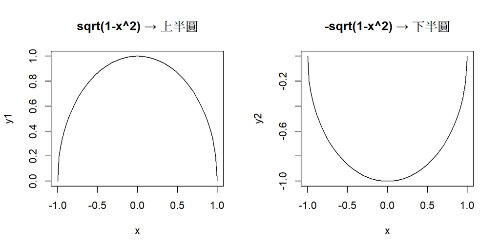

```r
par(mfrow=c(1,2))
curve(sqrt(1-x^2),-1,1,ylab = 'y1',main = 'sqrt(1-x^2) → 上半圓')
curve(-sqrt(1-x^2),-1,1,ylab = 'y2',main='-sqrt(1-x^2) → 下半圓')
```

(e)Use the dataset iris. Write a code to draw the plot:

```r
datasets::iris
```

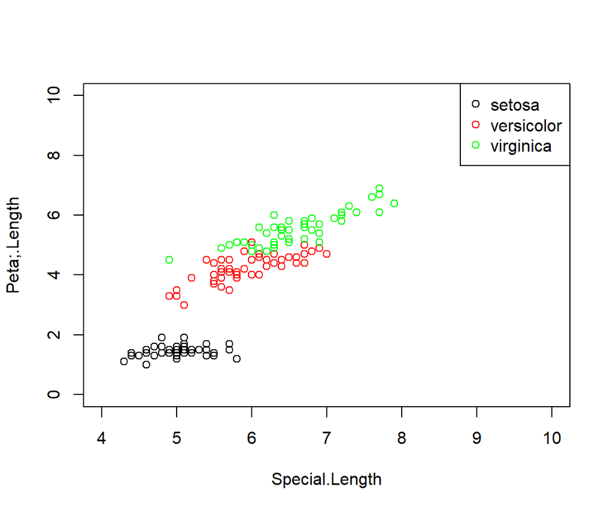

```r
plot(c(4,10),c(0,10),type = 'n',
     xlab = 'Special.Length',
     ylab = 'Peta;.Length')
for(i in 1:length(iris$Species)){
  if (iris$Species[i] == 'setosa'){
    points(iris$Sepal.Length[i],iris$Petal.Length[i],col='black')
  }else if (iris$Species[i]=='versicolor'){
    points(iris$Sepal.Length[i],iris$Petal.Length[i],col='red')
  }else{
    points(iris$Sepal.Length[i],iris$Petal.Length[i],col='green')
  }
}
legend('topright',c('setosa','versicolor','virginica'),col=c('black','red','green'),pch=c(1,1,1))
```

**2.** Download the package “titanic” and library(“titanic”). Use data(titanic_train) to the following questions:

1. Extract the column names of the dateset.

```r
library('titanic')
colnames(titanic_train)
```

```
##  [1] "PassengerId" "Survived"    "Pclass"      "Name"        "Sex"
##  [6] "Age"         "SibSp"       "Parch"       "Ticket"      "Fare"
## [11] "Cabin"       "Embarked"
```

2. How many people are there in the dataset? The column “Survived” is Passenger Survival Indicator with dead 0 and survival 1. How many survived people are there?

```r
#all people
length(titanic_train$Survived)
```

```
## [1] 891
```

```r
#survived people
sum(titanic_train$Survived)
```

```
## [1] 342
```

3. Draw two pie charts for the columns of Survived and Sex.

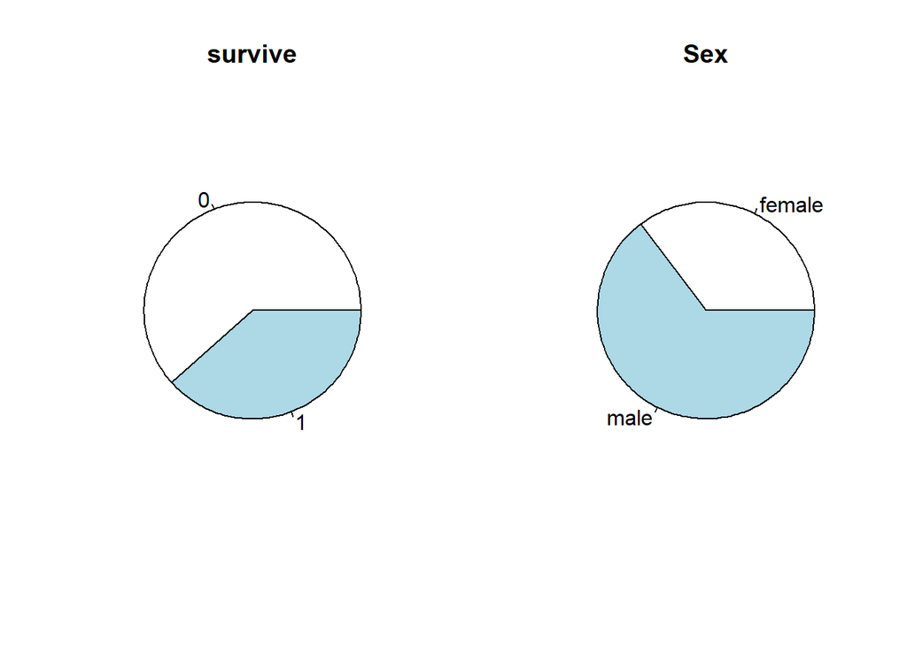

```r
par(mfrow=c(1,2))
x<-table(titanic_train$Survived)
pie(x,main = 'survive')
y<-table(titanic_train$Sex)
pie(y,main='Sex')
```

4. Provide the value of percentage of each gender in both survival group and dead group.

```r
g_s<-0;b_s<-0
g_d<-0;b_d<-0
for(i in 1:length(titanic_train$Survived)){
  if(titanic_train$Survived[i]==1){
    if(titanic_train$Sex[i]=='female'){
      g_s<-g_s+1
    }else{
      b_s<-b_s+1
    }
  }else{
    if(titanic_train$Sex[i]=='female'){
      g_d<-g_d+1
    }else{
      b_d<-b_d+1
    }
  }
}
paste('Survival_male:',b_s/(b_s+g_s)*100)
```

```
## [1] "Survival_male: 31.8713450292398"
```

```r
paste('Survival_female:',g_s/(b_s+g_s)*100)
```

```
## [1] "Survival_female: 68.1286549707602"
```

```r
paste('Dead_male:',b_d/(b_d+g_d)*100)
```

```
## [1] "Dead_male: 85.2459016393443"
```

```r
paste('Dead_female:',g_d/(b_d+g_d)*100)
```

```
## [1] "Dead_female: 14.7540983606557"
```

**3.** Let x <- seq(-1.5, 1.5, 0.01) and y <- seq(-1.5, 1.5, 0.01).

(a)Use a matrix to collect all possible combinations of x and y into a matrix satisfying
$$x^2y^3-(x^2+y^2-1)^3\geq0$$

```r
x <- seq(-1.5, 1.5, 0.01)
y <- seq(-1.5, 1.5, 0.01)
ma<-matrix(c(0,0),1,2)
for (i in 1:length(x)){
  if(x[i]^2*y[i]^2-(x[i]^2+y[i]^2-1)**3>=0){
    ma<-rbind(ma,c(x[i],y[i]))
  }
}
```

2. Draw a plot including all possible combinations in (a). What is the graph?

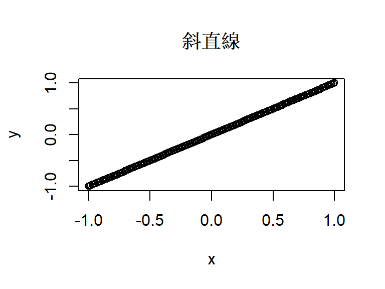

```r
plot(ma,xlab = 'x',ylab = 'y',main = '斜直線')
```

**4.** Download the package “nlme” and library(nlme). Begin with the data: data(Fatigue). There are three columns, which are “Path”, “cycles”, and “relLength”. **Path** means the ID number of a unit, **cycles** means the measurement time point, and **relLength** means the crack length over cycles. Use the Fatigue data to the following questions:

1. How many units are there in the dataset?

```r
library('nlme')
data(Fatigue)
length(unique(Fatigue$Path))
```

```
## [1] 21
```